# MAVE QC Report

MAVEQC-v0.2.2

2023-08-31 14:41:40

## 1. Introduction

MAVEQC is a flexible R-package that provides QC analysis of Saturation Genome Editing (SGE) experimental data. Available under GPL 3.0 from https://github.com/wtsi-hgi/MAVEQC

## 2. Screen QC

Displays QC plots and statistics for all samples for QC.

### 2.1. Sample Sheet

| sample_name | library_independent_count | library_dependent_count | valiant_meta | vep_anno | adapt5 | adapt3 | per_r1_adaptor | per_r2_adaptor | library_name | library_type |
| --- | --- | --- | --- | --- | --- | --- | --- | --- | --- | --- |
| hgeh2_d4_r1 | Rep1_HGEH2_Day4.query_counts.tsv.gz | Rep1_HGEH2_Day4.lib_counts.tsv.gz | meta.csv.gz | meta_consequences.tsv.gz | AATGATACGGCGACCACCGAATGTTCTTCTGGTGTGCCCTGCTCT | ACTTGTGAACTGTAAAACCTGAATGTCGTATGCCGTCTTCTGCTTG | 0.32921 | NA | EHMT1_exon25 | screen |
| hgeh2_d7_r1 | Rep1_HGEH2_Day7.query_counts.tsv.gz | Rep1_HGEH2_Day7.lib_counts.tsv.gz | meta.csv.gz | meta_consequences.tsv.gz | AATGATACGGCGACCACCGAATGTTCTTCTGGTGTGCCCTGCTCT | ACTTGTGAACTGTAAAACCTGAATGTCGTATGCCGTCTTCTGCTTG | 0.32948 | NA | EHMT1_exon25 | screen |
| hgeh2_d15_r1 | Rep1_HGEH2_Day15.query_counts.tsv.gz | Rep1_HGEH2_Day15.lib_counts.tsv.gz | meta.csv.gz | meta_consequences.tsv.gz | AATGATACGGCGACCACCGAATGTTCTTCTGGTGTGCCCTGCTCT | ACTTGTGAACTGTAAAACCTGAATGTCGTATGCCGTCTTCTGCTTG | 0.329091 | NA | EHMT1_exon25 | screen |
| hgeh2_d4_r2 | Rep2_HGEH2_Day4.query_counts.tsv.gz | Rep2_HGEH2_Day4.lib_counts.tsv.gz | meta.csv.gz | meta_consequences.tsv.gz | AATGATACGGCGACCACCGAATGTTCTTCTGGTGTGCCCTGCTCT | ACTTGTGAACTGTAAAACCTGAATGTCGTATGCCGTCTTCTGCTTG | 0.329308 | NA | EHMT1_exon25 | screen |
| hgeh2_d7_r2 | Rep2_HGEH2_Day7.query_counts.tsv.gz | Rep2_HGEH2_Day7.lib_counts.tsv.gz | meta.csv.gz | meta_consequences.tsv.gz | AATGATACGGCGACCACCGAATGTTCTTCTGGTGTGCCCTGCTCT | ACTTGTGAACTGTAAAACCTGAATGTCGTATGCCGTCTTCTGCTTG | 0.329664 | NA | EHMT1_exon25 | screen |
| hgeh2_d15_r2 | Rep2_HGEH2_Day15.query_counts.tsv.gz | Rep2_HGEH2_Day15.lib_counts.tsv.gz | meta.csv.gz | meta_consequences.tsv.gz | AATGATACGGCGACCACCGAATGTTCTTCTGGTGTGCCCTGCTCT | ACTTGTGAACTGTAAAACCTGAATGTCGTATGCCGTCTTCTGCTTG | 0.329328 | NA | EHMT1_exon25 | screen |
| hgeh2_d4_r3 | Rep3_HGEH2_Day4.query_counts.tsv.gz | Rep3_HGEH2_Day4.lib_counts.tsv.gz | meta.csv.gz | meta_consequences.tsv.gz | AATGATACGGCGACCACCGAATGTTCTTCTGGTGTGCCCTGCTCT | ACTTGTGAACTGTAAAACCTGAATGTCGTATGCCGTCTTCTGCTTG | 0.329049 | NA | EHMT1_exon25 | screen |
| hgeh2_d7_r3 | Rep3_HGEH2_Day7.query_counts.tsv.gz | Rep3_HGEH2_Day7.lib_counts.tsv.gz | meta.csv.gz | meta_consequences.tsv.gz | AATGATACGGCGACCACCGAATGTTCTTCTGGTGTGCCCTGCTCT | ACTTGTGAACTGTAAAACCTGAATGTCGTATGCCGTCTTCTGCTTG | 0.328999 | NA | EHMT1_exon25 | screen |
| hgeh2_d15_r3 | Rep3_HGEH2_Day15.query_counts.tsv.gz | Rep3_HGEH2_Day15.lib_counts.tsv.gz | meta.csv.gz | meta_consequences.tsv.gz | AATGATACGGCGACCACCGAATGTTCTTCTGGTGTGCCCTGCTCT | ACTTGTGAACTGTAAAACCTGAATGTCGTATGCCGTCTTCTGCTTG | 0.329525 | NA | EHMT1_exon25 | screen |

### 2.2. Run Sample QC

#### 2.2.1. Read Length Distrubtion

Displays the percentage of reads for each sample, based on 50 nucleotide increments.

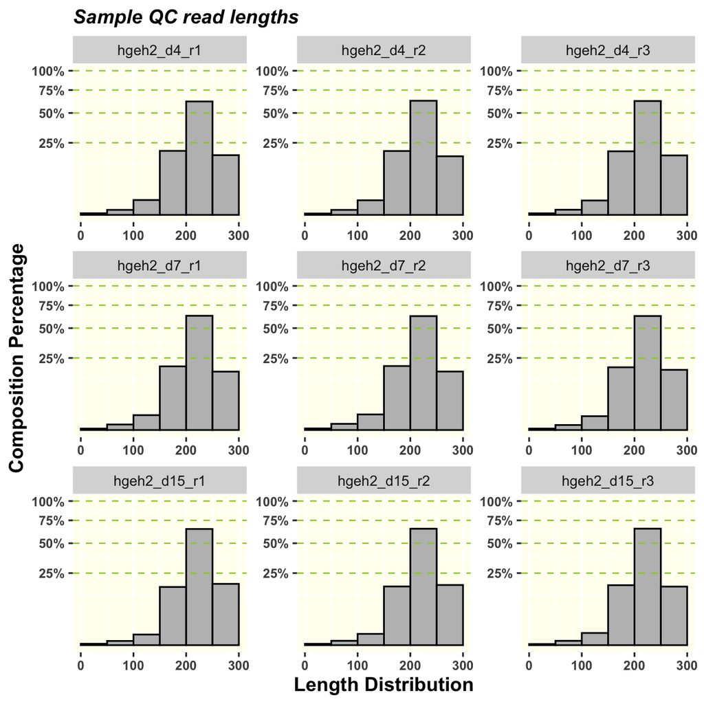

| Group | Sample | Total Reads | % 0 ~ 50 | % 50 ~ 100 | % 100 ~ 150 | % 150 ~ 200 | % 200 ~ 250 | % 250 ~ 300 | Pass Threshold | Pass |
| --- | --- | --- | --- | --- | --- | --- | --- | --- | --- | --- |
| EHMT1_exon25 | hgeh2_d4_r1 | 3902086 | 0 | 0.1 | 1.1 | 19.7 | 61.9 | 17.2 | 90 | False |
| EHMT1_exon25 | hgeh2_d4_r2 | 3172202 | 0 | 0.1 | 1 | 19.6 | 62.7 | 16.5 | 90 | False |
| EHMT1_exon25 | hgeh2_d4_r3 | 3347272 | 0 | 0.1 | 1 | 19.4 | 62.4 | 17 | 90 | False |
| EHMT1_exon25 | hgeh2_d7_r1 | 3803227 | 0 | 0.1 | 1.1 | 19.5 | 62.8 | 16.4 | 90 | False |
| EHMT1_exon25 | hgeh2_d7_r2 | 3285337 | 0 | 0.2 | 1.2 | 19.7 | 62.5 | 16.5 | 90 | False |
| EHMT1_exon25 | hgeh2_d7_r3 | 3491267 | 0 | 0.1 | 0.9 | 19 | 62.6 | 17.4 | 90 | False |
| EHMT1_exon25 | hgeh2_d15_r1 | 4003945 | 0 | 0.1 | 0.5 | 16.3 | 65 | 18.1 | 90 | False |
| EHMT1_exon25 | hgeh2_d15_r2 | 3695427 | 0 | 0.1 | 0.6 | 16.6 | 65.3 | 17.4 | 90 | False |
| EHMT1_exon25 | hgeh2_d15_r3 | 3793708 | 0 | 0.1 | 0.7 | 17.3 | 65.4 | 16.5 | 90 | False |

#### 2.2.2. Missing Variants

Missing variants in the library

| Group | Sample | Library Sequences | Missing Library Sequences | % Missing Library Sequences | Pass Threshold | Pass |
| --- | --- | --- | --- | --- | --- | --- |
| EHMT1_exon25 | hgeh2_d4_r1 | 980 | 2 | 0.2 | 1 | True |
| EHMT1_exon25 | hgeh2_d4_r2 | 980 | 2 | 0.2 | 1 | True |
| EHMT1_exon25 | hgeh2_d4_r3 | 980 | 2 | 0.2 | 1 | True |
| EHMT1_exon25 | hgeh2_d7_r1 | 980 | 2 | 0.2 | 1 | True |
| EHMT1_exon25 | hgeh2_d7_r2 | 980 | 2 | 0.2 | 1 | True |
| EHMT1_exon25 | hgeh2_d7_r3 | 980 | 2 | 0.2 | 1 | True |
| EHMT1_exon25 | hgeh2_d15_r1 | 980 | 2 | 0.2 | 1 | True |
| EHMT1_exon25 | hgeh2_d15_r2 | 980 | 2 | 0.2 | 1 | True |
| EHMT1_exon25 | hgeh2_d15_r3 | 980 | 2 | 0.2 | 1 | True |

| name | length | count | unique | sample |
| --- | --- | --- | --- | --- |
| ENST00000460843.6.ENSG00000181090.21_chr9:137817970_T>C_UKBB_EHMT1 | 292 | 0 | 1 | SGE_1062686848_Rep1_HGEH2_Day15 |
| ENST00000460843.6.ENSG00000181090.21_chr9:137817970_T>C_UKBB_EHMT1 | 292 | 0 | 1 | SGE_1062686848_Rep1_HGEH2_Day4 |
| ENST00000460843.6.ENSG00000181090.21_chr9:137817970_T>C_UKBB_EHMT1 | 292 | 0 | 1 | SGE_1062686848_Rep1_HGEH2_Day7 |
| ENST00000460843.6.ENSG00000181090.21_chr9:137817970_T>C_UKBB_EHMT1 | 292 | 0 | 1 | SGE_1062686848_Rep2_HGEH2_Day15 |
| ENST00000460843.6.ENSG00000181090.21_chr9:137817970_T>C_UKBB_EHMT1 | 292 | 0 | 1 | SGE_1062686848_Rep2_HGEH2_Day4 |
| ENST00000460843.6.ENSG00000181090.21_chr9:137817970_T>C_UKBB_EHMT1 | 292 | 0 | 1 | SGE_1062686848_Rep2_HGEH2_Day7 |
| ENST00000460843.6.ENSG00000181090.21_chr9:137817970_T>C_UKBB_EHMT1 | 292 | 0 | 1 | SGE_1062686848_Rep3_HGEH2_Day15 |
| ENST00000460843.6.ENSG00000181090.21_chr9:137817970_T>C_UKBB_EHMT1 | 292 | 0 | 1 | SGE_1062686848_Rep3_HGEH2_Day4 |
| ENST00000460843.6.ENSG00000181090.21_chr9:137817970_T>C_UKBB_EHMT1 | 292 | 0 | 1 | SGE_1062686848_Rep3_HGEH2_Day7 |
| ENST00000460843.6.ENSG00000181090.21_chr9:137817969_C>T_UKBB_EHMT1 | 292 | 0 | 1 | SGE_1062686848_Rep1_HGEH2_Day15 |

[output cut: 8 more lines]

#### 2.2.3. Total Reads

Displays the total number of reads per sample. Filtering based on 1-dimensional Kmean clustering that excludes unique sequences with low read counts.

- **Accepted reads**: Total read count for all unique sequences with sufficient reads.
- **Excluded reads**: Total read count for all unique sequences with insufficient reads.

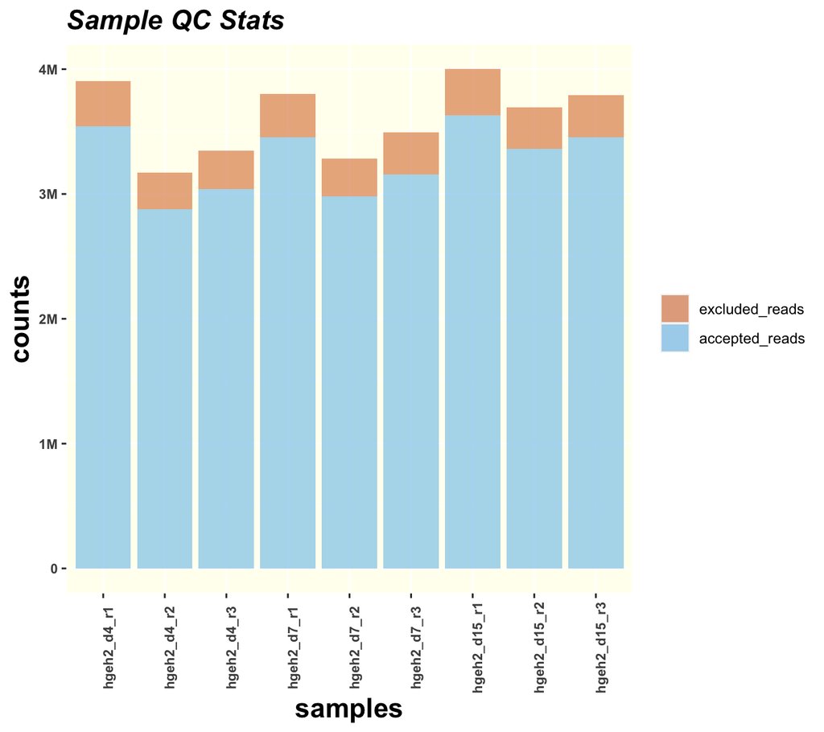

| Group | Sample | Accepted Reads | % Accepted Reads | Excluded Reads | % Excluded Reads | Total Reads | Pass Threshold | Pass |
| --- | --- | --- | --- | --- | --- | --- | --- | --- |
| EHMT1_exon25 | hgeh2_d4_r1 | 3541955 | 90.8 | 360131 | 9.2 | 3902086 | 1000000 | True |
| EHMT1_exon25 | hgeh2_d4_r2 | 2879877 | 90.8 | 292325 | 9.2 | 3172202 | 1000000 | True |
| EHMT1_exon25 | hgeh2_d4_r3 | 3038285 | 90.8 | 308987 | 9.2 | 3347272 | 1000000 | True |
| EHMT1_exon25 | hgeh2_d7_r1 | 3454733 | 90.8 | 348494 | 9.2 | 3803227 | 1000000 | True |
| EHMT1_exon25 | hgeh2_d7_r2 | 2980156 | 90.7 | 305181 | 9.3 | 3285337 | 1000000 | True |
| EHMT1_exon25 | hgeh2_d7_r3 | 3156069 | 90.4 | 335198 | 9.6 | 3491267 | 1000000 | True |
| EHMT1_exon25 | hgeh2_d15_r1 | 3630160 | 90.7 | 373785 | 9.3 | 4003945 | 1000000 | True |
| EHMT1_exon25 | hgeh2_d15_r2 | 3361917 | 91 | 333510 | 9 | 3695427 | 1000000 | True |
| EHMT1_exon25 | hgeh2_d15_r3 | 3453838 | 91 | 339870 | 9 | 3793708 | 1000000 | True |

#### 2.2.4. Accepted Reads

Displays the percentage of library reads vs non-library reads (ie. Reference, PAM and Unmapped) for Accepted Reads.

- **Library Reads**: Percentage reads mapping to template oligo sequences, including intended variants.
- **Reference Reads**: Percentage reads mapping to Reference.
- **PAM_Reads**: Percentage reads mapping to PAM/Protospacer Protection Edits (PPEs), without intended variant.
- **Unmapped Reads**: Percentage of Unmapped Reads.

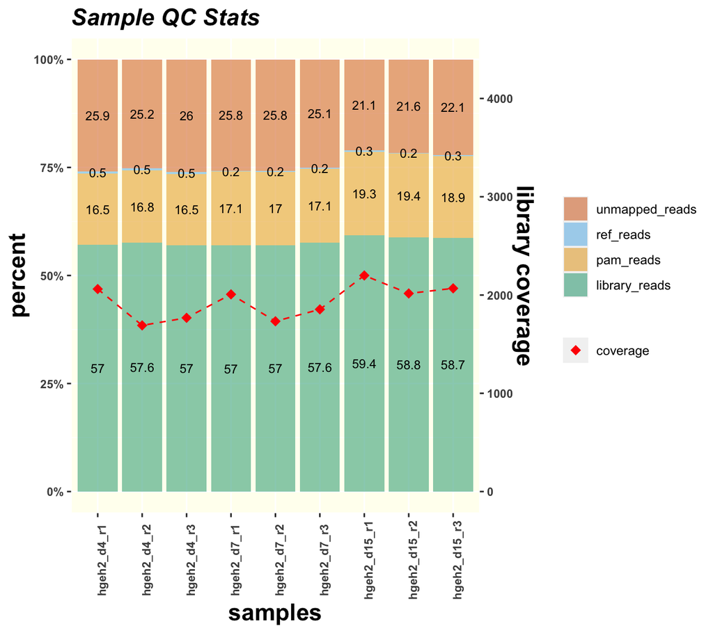

| Group | Sample | % Library Reads | % Reference Reads | % PAM Reads | % Unmapped Reads | Pass Threshold | Pass |
| --- | --- | --- | --- | --- | --- | --- | --- |
| EHMT1_exon25 | hgeh2_d4_r1 | 57 | 0.5 | 16.5 | 25.9 | 40 | True |
| EHMT1_exon25 | hgeh2_d4_r2 | 57.6 | 0.5 | 16.8 | 25.2 | 40 | True |
| EHMT1_exon25 | hgeh2_d4_r3 | 57 | 0.5 | 16.5 | 26 | 40 | True |
| EHMT1_exon25 | hgeh2_d7_r1 | 57 | 0.2 | 17.1 | 25.8 | 40 | True |
| EHMT1_exon25 | hgeh2_d7_r2 | 57 | 0.2 | 17 | 25.8 | 40 | True |
| EHMT1_exon25 | hgeh2_d7_r3 | 57.6 | 0.2 | 17.1 | 25.1 | 40 | True |
| EHMT1_exon25 | hgeh2_d15_r1 | 59.4 | 0.3 | 19.3 | 21.1 | 40 | True |
| EHMT1_exon25 | hgeh2_d15_r2 | 58.8 | 0.2 | 19.4 | 21.6 | 40 | True |
| EHMT1_exon25 | hgeh2_d15_r3 | 58.7 | 0.3 | 18.9 | 22.1 | 40 | True |

Defines the mean read count per template oligo sequence.

| Group | Sample | Total Library Reads | Total Library Sequences | Library Coverage | Median Coverage | Pass Threshold | Pass |
| --- | --- | --- | --- | --- | --- | --- | --- |
| EHMT1_exon25 | hgeh2_d4_r1 | 2019894 | 980 | 2061 | 1759.5 | 100 | True |
| EHMT1_exon25 | hgeh2_d4_r2 | 1657581 | 980 | 1691 | 1418 | 100 | True |
| EHMT1_exon25 | hgeh2_d4_r3 | 1732743 | 980 | 1768 | 1505 | 100 | True |
| EHMT1_exon25 | hgeh2_d7_r1 | 1967802 | 980 | 2007 | 1708.5 | 100 | True |
| EHMT1_exon25 | hgeh2_d7_r2 | 1698546 | 980 | 1733 | 1469.5 | 100 | True |
| EHMT1_exon25 | hgeh2_d7_r3 | 1817420 | 980 | 1854 | 1568.5 | 100 | True |
| EHMT1_exon25 | hgeh2_d15_r1 | 2155131 | 980 | 2199 | 1879 | 100 | True |
| EHMT1_exon25 | hgeh2_d15_r2 | 1976207 | 980 | 2016 | 1743 | 100 | True |
| EHMT1_exon25 | hgeh2_d15_r3 | 2026815 | 980 | 2068 | 1775.5 | 100 | True |

#### 2.2.5. Genomic Coverage

Distribution of variants across targeton region based on log2(count+1) values.

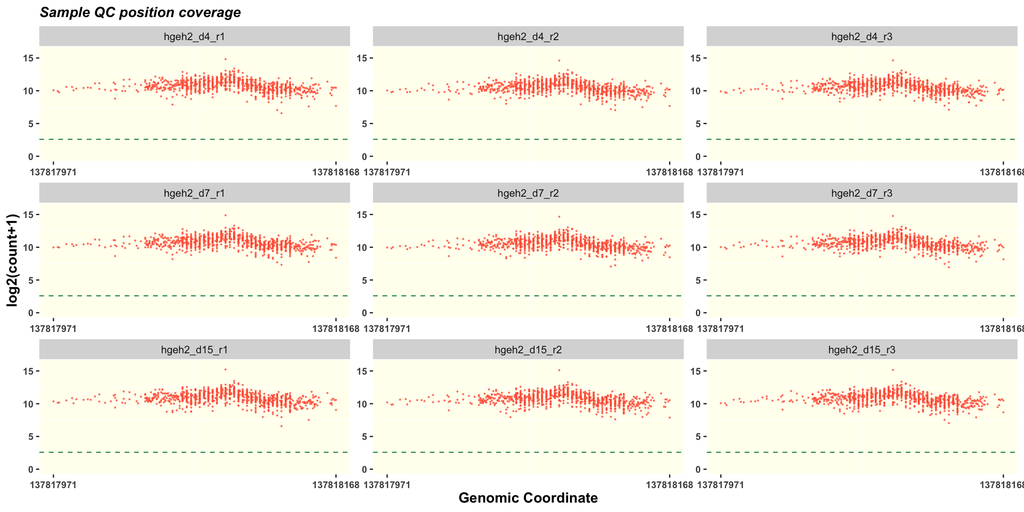

| Group | Sample | Chromosome | Strand | Genomic Start | Genomic End | % Low Abundance | Low Abundance cutoff | Pass Threshold | Pass |
| --- | --- | --- | --- | --- | --- | --- | --- | --- | --- |
| EHMT1_exon25 | hgeh2_d4_r1 | chr9 | + | 137817946 | 137818196 | 0 | 5 | 30 | True |
| EHMT1_exon25 | hgeh2_d4_r2 | chr9 | + | 137817946 | 137818196 | 0 | 5 | 30 | True |
| EHMT1_exon25 | hgeh2_d4_r3 | chr9 | + | 137817946 | 137818196 | 0 | 5 | 30 | True |
| EHMT1_exon25 | hgeh2_d7_r1 | chr9 | + | 137817946 | 137818196 | 0 | 5 | 30 | True |
| EHMT1_exon25 | hgeh2_d7_r2 | chr9 | + | 137817946 | 137818196 | 0 | 5 | 30 | True |
| EHMT1_exon25 | hgeh2_d7_r3 | chr9 | + | 137817946 | 137818196 | 0 | 5 | 30 | True |
| EHMT1_exon25 | hgeh2_d15_r1 | chr9 | + | 137817946 | 137818196 | 0 | 5 | 30 | True |
| EHMT1_exon25 | hgeh2_d15_r2 | chr9 | + | 137817946 | 137818196 | 0 | 5 | 30 | True |
| EHMT1_exon25 | hgeh2_d15_r3 | chr9 | + | 137817946 | 137818196 | 0 | 5 | 30 | True |

#### 2.2.6. Genomic Position Percentage

Displays distribution of “LOF” (loss-of-function) vs all “Other” variants across the targeton region, based on read percentages for reference timepoint. Requires concordant distribution of LOF and Other variants.

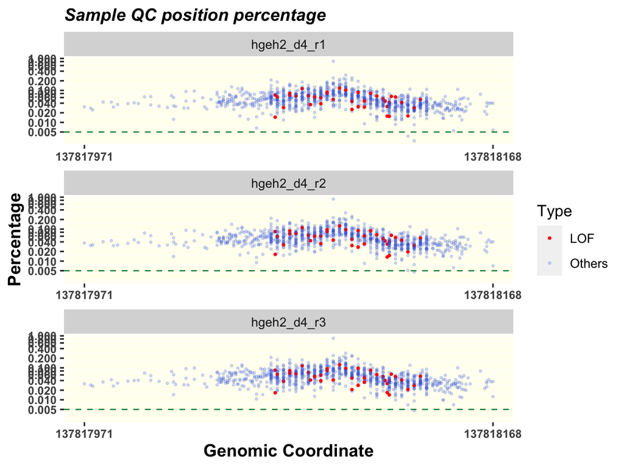

| Group | Sample | Chromosome | Strand | Genomic Start | Genomic End | % Low Abundance (LOF) | % Low Abundance (Others) | % Low Abundance (ALL) | % Low Abundance cutoff | Pass Threshold | Pass |
| --- | --- | --- | --- | --- | --- | --- | --- | --- | --- | --- | --- |
| EHMT1_exon25 | hgeh2_d4_r1 | chr9 | + | 137817946 | 137818196 | 0 | 0.2 | 0.2 | 0.005 | 30 | True |
| EHMT1_exon25 | hgeh2_d4_r2 | chr9 | + | 137817946 | 137818196 | 0 | 0.1 | 0.1 | 0.005 | 30 | True |
| EHMT1_exon25 | hgeh2_d4_r3 | chr9 | + | 137817946 | 137818196 | 0 | 0.1 | 0.1 | 0.005 | 30 | True |
| EHMT1_exon25 | hgeh2_d7_r1 | chr9 | + | 137817946 | 137818196 | 0 | 0.1 | 0.1 | 0.005 | 30 | True |
| EHMT1_exon25 | hgeh2_d7_r2 | chr9 | + | 137817946 | 137818196 | 0 | 0.1 | 0.1 | 0.005 | 30 | True |
| EHMT1_exon25 | hgeh2_d7_r3 | chr9 | + | 137817946 | 137818196 | 0 | 0.1 | 0.1 | 0.005 | 30 | True |
| EHMT1_exon25 | hgeh2_d15_r1 | chr9 | + | 137817946 | 137818196 | 0 | 0.1 | 0.1 | 0.005 | 30 | True |
| EHMT1_exon25 | hgeh2_d15_r2 | chr9 | + | 137817946 | 137818196 | 0 | 0 | 0 | 0.005 | 30 | True |
| EHMT1_exon25 | hgeh2_d15_r3 | chr9 | + | 137817946 | 137818196 | 0 | 0.1 | 0.1 | 0.005 | 30 | True |

### 2.3. Run Experiment QC

#### 2.3.1. Sample Correlations

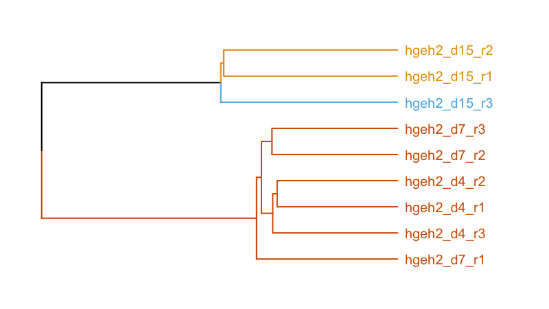

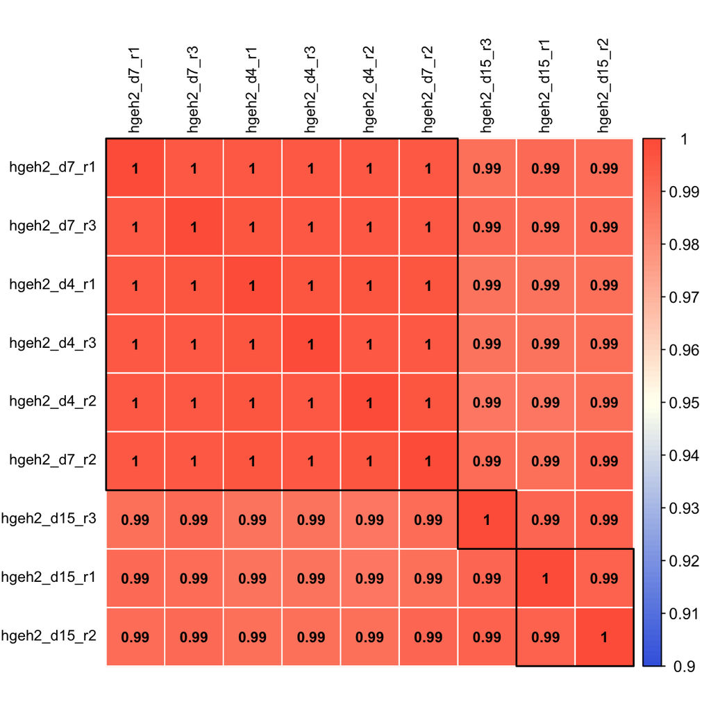

| Sample | Cluster | Replicate | Condition | hgeh2_d4_r1 | hgeh2_d7_r1 | hgeh2_d15_r1 | hgeh2_d4_r2 | hgeh2_d7_r2 | hgeh2_d15_r2 | hgeh2_d4_r3 | hgeh2_d7_r3 | hgeh2_d15_r3 | Pass |
| --- | --- | --- | --- | --- | --- | --- | --- | --- | --- | --- | --- | --- | --- |
| hgeh2_d4_r1 | 1 | R1 | D4 | 1 | 1 | 0.99 | 1 | 1 | 0.99 | 1 | 1 | 0.99 | False |
| hgeh2_d4_r2 | 1 | R2 | D4 | 1 | 1 | 0.99 | 1 | 1 | 0.99 | 1 | 1 | 0.99 | False |
| hgeh2_d4_r3 | 1 | R3 | D4 | 1 | 1 | 0.99 | 1 | 1 | 0.99 | 1 | 1 | 0.99 | False |
| hgeh2_d7_r1 | 1 | R1 | D7 | 1 | 1 | 0.99 | 1 | 1 | 0.99 | 1 | 1 | 0.99 | False |
| hgeh2_d7_r2 | 1 | R2 | D7 | 1 | 1 | 0.99 | 1 | 1 | 0.99 | 1 | 1 | 0.99 | False |
| hgeh2_d7_r3 | 1 | R3 | D7 | 1 | 1 | 0.99 | 1 | 1 | 0.99 | 1 | 1 | 0.99 | False |
| hgeh2_d15_r1 | 2 | R1 | D15 | 0.99 | 0.99 | 1 | 0.99 | 0.99 | 0.99 | 0.99 | 0.99 | 0.99 | False |
| hgeh2_d15_r2 | 2 | R2 | D15 | 0.99 | 0.99 | 0.99 | 0.99 | 0.99 | 1 | 0.99 | 0.99 | 0.99 | False |
| hgeh2_d15_r3 | 3 | R3 | D15 | 0.99 | 0.99 | 0.99 | 0.99 | 0.99 | 0.99 | 0.99 | 0.99 | 1 | False |

#### 2.3.2. Sample PCA

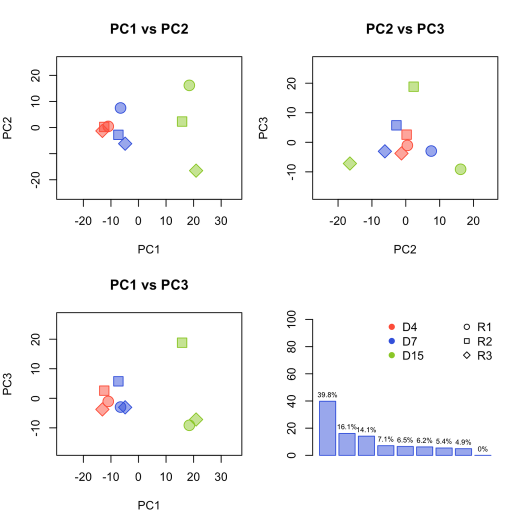

#### 2.3.3. Fold Change (by category)

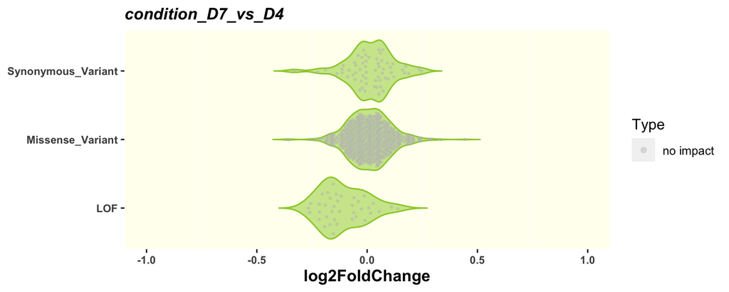

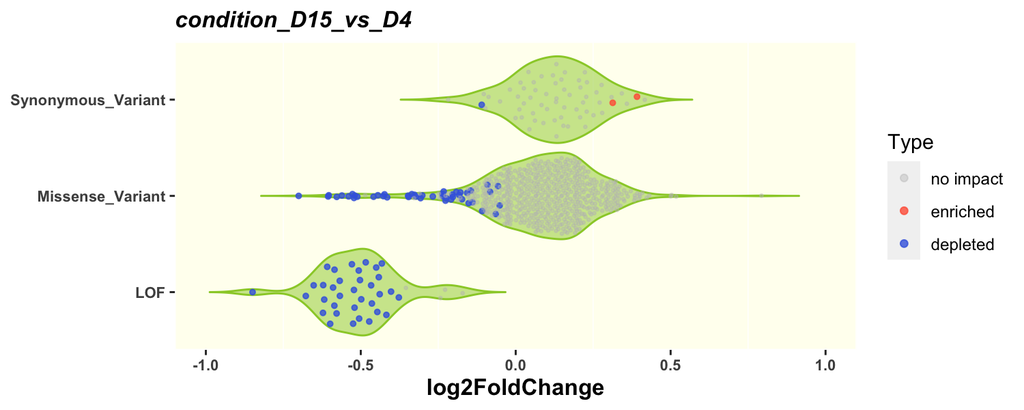

#### 2.3.4. Fold Change (by position)

**condition_D7_vs_D4**

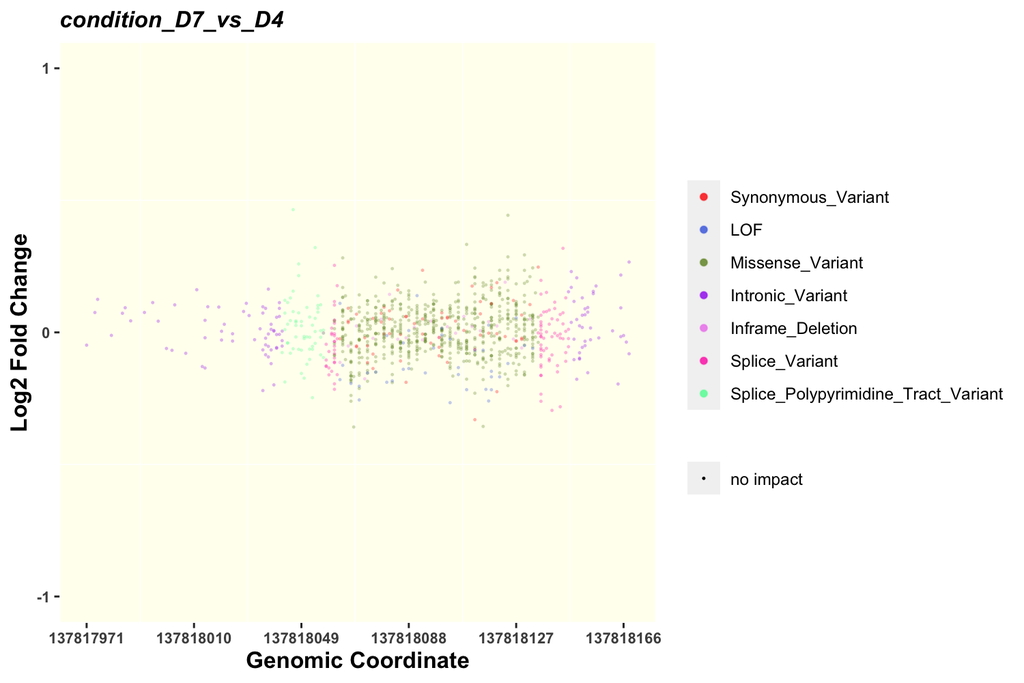

| oligo_name | consequence | position | adj_log2FoldChange | adj_fdr | stat |
| --- | --- | --- | --- | --- | --- |

**condition_D15_vs_D4**

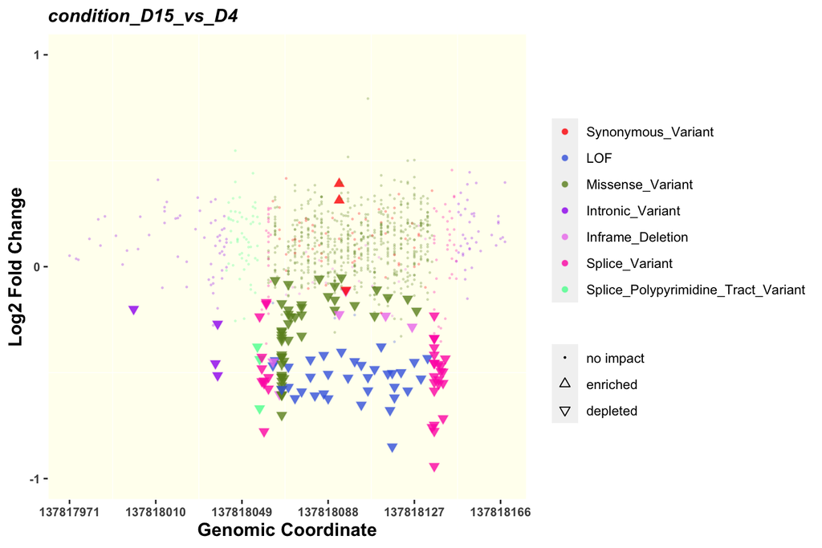

| oligo_name | consequence | position | adj_log2FoldChange | adj_fdr | stat |
| --- | --- | --- | --- | --- | --- |
| ENST00000460843.6.ENSG00000181090.21_chr9:137818093_T>C_snv | Synonymous_Variant | 137818093 | 0.181837367554795 | 4.67453558606061e-08 | enriched |
| ENST00000460843.6.ENSG00000181090.21_chr9:137818076_137818078_ATT>TGA_stop | LOF | 137818076 | -0.720727296561626 | 7.73049133071034e-26 | depleted |
| ENST00000460843.6.ENSG00000181090.21_chr9:137818061_137818063_TAT>TGA_snvre | Splice_Variant | 137818061 | -0.652777350679097 | 2.13594190658106e-25 | depleted |
| ENST00000460843.6.ENSG00000181090.21_chr9:137818067_137818069_GGG>CAG_aa | Missense_Variant | 137818067 | -0.831684873667268 | 5.34887210393153e-18 | depleted |
| ENST00000460843.6.ENSG00000181090.21_chr9:137818067_137818069_inframe | Inframe_Deletion | 137818066 | -0.733803869409935 | 8.95826236740893e-17 | depleted |
| ENST00000460843.6.ENSG00000181090.21_chr9:137818097_137818099_GTC>TGA_stop | LOF | 137818097 | -0.655944878160803 | 1.67850873682429e-17 | depleted |
| ENST00000460843.6.ENSG00000181090.21_chr9:137818119_137818125_Clinvar | LOF | 137818118 | -0.698694154227919 | 1.08070490267079e-16 | depleted |
| ENST00000460843.6.ENSG00000181090.21_chr9:137818088_137818090_GAA>TGA_snvre | LOF | 137818088 | -0.753286099493368 | 3.86182944903554e-16 | depleted |
| ENST00000460843.6.ENSG00000181090.21_chr9:137818136_137818138_AAG>GGC_aa | Splice_Variant | 137818136 | -1.07276216656287 | 4.68080431528027e-14 | depleted |
| ENST00000460843.6.ENSG00000181090.21_chr9:137818136_137818138_inframe | Splice_Variant | 137818135 | -0.888915323631537 | 3.6703359870934e-14 | depleted |

[output cut: 119 more lines]

## 3. QC Results

Summarising the final results, below are the cutoffs using for PASS/FAIL

[output not shown]

### 3.1. Sample QC Results

| Group | Sample | Gini Coefficient | Total Reads | % Missing Variants | Accepted Reads | % Mapping Reads | % Reference Reads | % Library Reads | Library Coverage | % R1 Adatpor | % R2 Adaptor |
| --- | --- | --- | --- | --- | --- | --- | --- | --- | --- | --- | --- |
| EHMT1_exon25 | hgeh2_d4_r1 | 0.469 | True | True | True | True | True | True | True | 0.3292 | 0 |
| EHMT1_exon25 | hgeh2_d4_r2 | 0.472 | True | True | True | True | True | True | True | 0.3293 | 0 |
| EHMT1_exon25 | hgeh2_d4_r3 | 0.468 | True | True | True | True | True | True | True | 0.329 | 0 |
| EHMT1_exon25 | hgeh2_d7_r1 | 0.473 | True | True | True | True | True | True | True | 0.3295 | 0 |
| EHMT1_exon25 | hgeh2_d7_r2 | 0.472 | True | True | True | True | True | True | True | 0.3297 | 0 |
| EHMT1_exon25 | hgeh2_d7_r3 | 0.47 | True | True | True | True | True | True | True | 0.329 | 0 |
| EHMT1_exon25 | hgeh2_d15_r1 | 0.487 | True | True | True | True | True | True | True | 0.3291 | 0 |
| EHMT1_exon25 | hgeh2_d15_r2 | 0.488 | True | True | True | True | True | True | True | 0.3293 | 0 |
| EHMT1_exon25 | hgeh2_d15_r3 | 0.484 | True | True | True | True | True | True | True | 0.3295 | 0 |